# Synthetic Data Generation Demo with synthpop

### Load Libraries & sample data

```r
# load libraries
library(synthpop)
```

```r
library(ggplot2)
library(dplyr)
# load the data
synth_og <- read.csv("../data/data_new.csv")


# take a random sample of 100 rows to keep things fast and readable
# NOTE: Small sample size used intentionally for purpose of demo
sm_sample <- synth_og %>% sample_n(100)
```

### Generate Synthetic Data

```r
# Generate synthetic data with all output silenced
tmp <- capture.output({
  syn_model <- syn(sm_sample, seed = 123)
})

# Extract the synthetic dataset
syn_dat <- syn_model$syn

# Create plot_df for ggplot
plot_df <- rbind(
  data.frame(cost_t = sm_sample$cost_t, source = "Original"),
  data.frame(cost_t = syn_dat$cost_t, source = "Synthetic")
)
```

### Synthetic vs Real Data

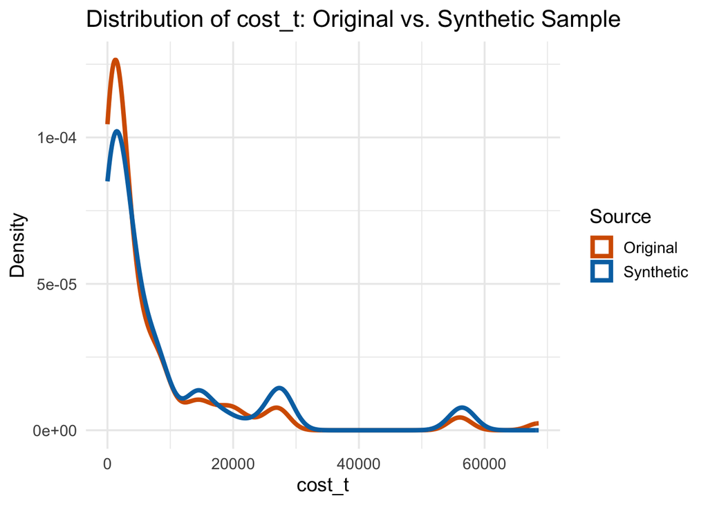

```r
ggplot(plot_df, aes(x = cost_t, color = source)) +
  geom_density(size = 1.5) +
  scale_color_manual(values = c("Original" = "#D55E00", "Synthetic" = "#0072B2")) +
  labs(
    title = "Distribution of cost_t: Original vs. Synthetic Sample",
    x = "cost_t", y = "Density",
    color = "Source"
  ) +
  theme_minimal(base_size = 14)
```

### Compare Variables

```r
# Compare key variables
compare(
  syn_model,
  data = sm_sample,
  vars = c("cost_t", "gagne_sum_t", "risk_score_t")
)
```

```
## Calculations done for cost_t
## Calculations done for gagne_sum_t
## Calculations done for risk_score_t
```

```
##
## Comparing percentages observed with synthetic
```

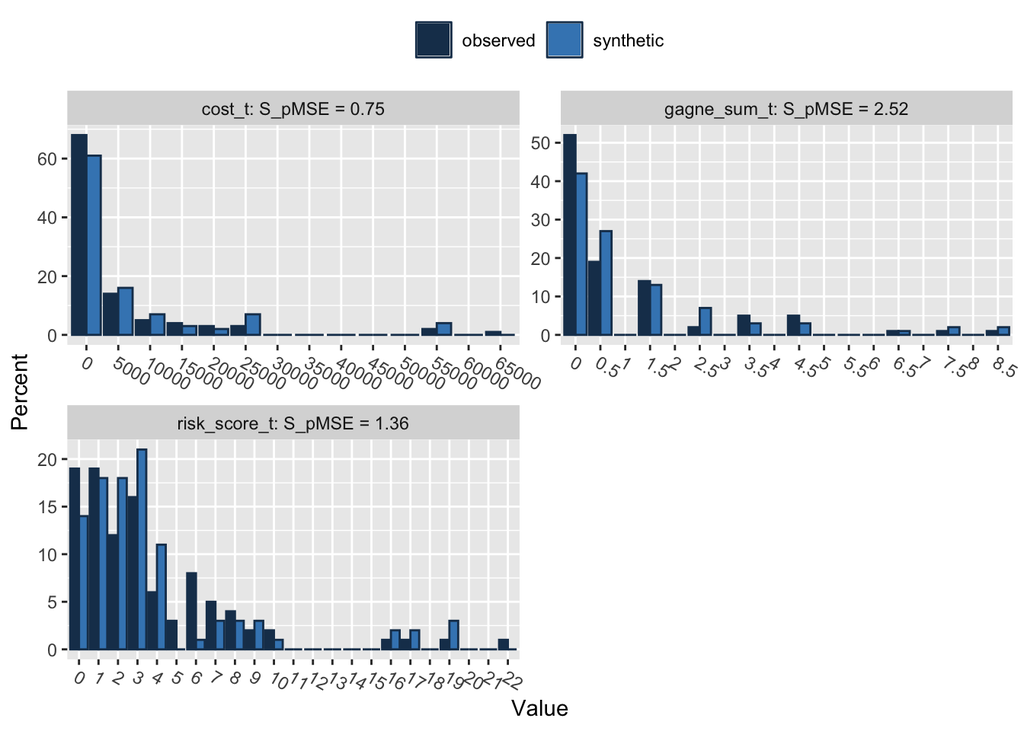

```
##
## Selected utility measures:
##                  pMSE   S_pMSE df
## cost_t       0.001886 0.754328  4
## gagne_sum_t  0.003152 2.521801  2
## risk_score_t 0.003404 1.361704  4
```

### Conclusion

The purpose of this notebook was to demonstrate how the `synthpop` package in R works — specifically, to showcase the process used to generate the synthetic dataset provided by Obermeyer et al and used in our audit of healthcare algorithm bias.

However, this demonstration also highlights important **limitations of `synthpop`**: - It does **not preserve temporal patterns**, which are critical in longitudinal healthcare modeling. - Rare edge cases and anomalies tend to be smoothed out, potentially underrepresenting high-risk subgroups. - Relationships involving **unmeasured confounders or system-level bias** (e.g., care access disparities) are not recoverable through synthetic data alone.

Ultimately, this notebook is not meant to re-synthesize the dataset, but rather to **transparently document the statistical mechanism** through which the original study’s authors created their publicly shareable dataset. This ensures that downstream audit work — including fairness analysis and model reproduction — is grounded in a clear understanding of how the underlying data was generated.